# R and PostGIS: A Pragmatic Approach

Jamaal Green

3/5/2018

# Introduction

- We’ve got a powerful new tool in PostGIS and SQL
- This processing, while vital, is only a fraction of our workflow
- We still fall into the trap of intermediate files bloating directories and application jumping (PostGIS -> QGIS -> R/Python/SPSS -> Word Processor)

# You know some SQL…now what?

SQL is the true language of data science, but we see its limitations.

R offers a set of tools and approaches that can make querying relational databases less painful. Doubly so for spatial analysis.

# R and ‘sf’…spatial game changers

- R is an open source statistical programming language used by millions of people around the world
- ‘sf’ (simple features) is a package that uses PostGIS oriented WKT formats to define spatial objects and perform spatial operatios

# Why R?

- It’s *free*
- A bevy of well supported packages and active development community
- A full programming language that allows you to do everything from modeling to app design to data visualization
- It’s *free*

# ‘sf’

- Interfaces with the main spatial libraries we’ve heard about (GEOS, GDAL, and PROJ.4)
- Is the chosen successor for the older ‘sp’ package
- Also interfaces with DBI (database interface package that let’s us talk to PostGIS)

# Why is ‘sf’ awesome?

- ‘sf’ is FAST…uses spatial indices for operations in addition to the C-backed spatial libraries of GDAL and GEOS
- ‘sf’ talks to PostGIS for both reading and writing files and allows for arbitrarily complex queries from R (don’t open Postgres or pgadmin unless you want to)
- ‘sf’ objects are treated like regular data frames (major upgrade from ‘sp’)
- It’s *free*
- Built around “tidyverse” packages

# An exceedingly brief intro to the tidyverse…

- A set of packages created and maintained by RStudio built around the idea of working with ‘tidy’ data and programming support.
- Tidy data roughly == ‘long’ data…every column a variable, and every row an observation
- This data structure allows for easier table split-apply-combine functions, data visualization, modeling etc

# Yeah, yeah…prove it

Our research question: What effect does the presence of schools in census block groups have on median housing value?

What we need…

- Basic demos from block groups (% of total population)
- Median housing value
- School information for each block group (no. of schools, number of type of schools)

# The set up

```
if(!require(pacman)){install.packages("pacman"); library(pacman)}
p_load(tidycensus, tidyr, sf, RPostgres, ggplot2, dplyr)

host <- "http://learn-pgsql.rc.pdx.edu/"
db <- "jamgreen"
user <- "jamgreen"
pw <- scan("batteries.pgpss", what = "")

con <- dbConnect(drv = RPostgres::Postgres(), dbname = 'jamgreen',
                 host = 'learn-pgsql.rc.pdx.edu',
                 port = 5432, password = pw, user = 'jamgreen')

#some convenience functions

dbListTables(conn = con)
dbListFields(conn = con, name = "schools")
```

# Get schools and demographics the SQL way!

How should we solve this?

# My approach…if you know a more efficient way, please help me

```
mult_school_pgsql <- st_read_db(conn = con, query = "SELECT c.fips as fips,
c.pop10 as tot_pop2010, c.white as nh_white, c.black as nh_black,
c.asian asnh_asian, c.hispanic as hispanic, a.school_id as school_id,
a.school_name as school_name, a.school_grade as school_grade,
a.school_type as school_type, c.county as county,  c.geom
  FROM (SELECT a.fips as fips,  b.school_id as school_id,
  b.name as school_name, b.grade as school_grade,
  b.type as school_type, b.county as county, a.geom
  FROM blockgrp2010 a JOIN
  schools b ON ST_Intersects(a.geom, b.geom)
  WHERE b.county = 'Multnomah' AND  b.grade IS NOT NULL
  ORDER BY a.fips) as a
  RIGHT JOIN blockgrp2010 c ON
  c.fips = a.fips
  WHERE c.county = '051';")
```

# Demos and Schools the R (tidyverse) way

```
mult_school_tidy <- st_read_db(conn = con, query = "SELECT a.fips as fips,
b.school_id as school_id,  b.name as school_name, b.grade as school_grade,
b.type as school_type, b.county as county, a.geom
  FROM blockgrp2010 a JOIN schools b
  ON ST_Intersects(a.geom, b.geom)
  WHERE b.county = 'Multnomah' AND  b.grade IS NOT NULL
  ORDER BY a.fips;")

mult_block_grp <- st_read_db(conn = con, query = "SELECT fips,
pop10 as total_pop, white as nh_white, black as nh_black,
asian as nh_asian, hispanic as hispanic, geom
                            FROM blockgrp2010
                             WHERE county = '051';")

mult_school_tidy <-
right_join(data.frame(mult_school_tidy), mult_block_grp, by = "fips")

mult_school_tidy <- mult_school_tidy %>% select(-geom.x) %>%
  rename(geom = geom.y) %>% st_as_sf()
```

# A Quick Look

[interactive chart not shown]

# What’s with %>% ?

This is the tidyverse “pipe”…allows us to feed an object from the left to right hand side…allows us to chain a series of functions on an object

Allows for more easily readable and understandable code…though here, it may not be as efficient

# Let’s get these schools organized

The problem: we want number of schools, by type, by block group…this would be even more complicated in SQL (unless you have a way of doing this without the creation of a new table or view)

# Tidyverse to the rescue

```
 school_count <- mult_school_pgsql %>% filter(!is.na(school_name)) %>%
  group_by(fips, school_type) %>% summarise(school_count= n()) %>%
  as.data.frame() %>% select(-geom)

school_count <- spread(school_count, key = school_type, value = school_count)

school_count <- school_count %>%
  mutate(school_count = Public + Private)

mult_school_pgsql <- mult_school_pgsql %>%
  left_join(school_count, by = "fips")

mult_school_pgsql <- mult_school_pgsql %>%
  select(1:6, 12:15) %>%
  distinct(fips, .keep_all = TRUE)

mult_school_pgsql[is.na(mult_school_pgsql)] <- 0
```

# What happened?

We still had to create a new table and join back to the original…but look at what the %>% gives us around legibility…What would the SQL for this look like do we think?

# But wait…something’s missing…

- WHERE ARE OUR HOUSING VALUES?!?!?!
- Please don’t tell me I have to go to FactFinder…anything but that!
- You don’t…R to the rescue with *tidycensus*

# Get Median Housing Value by block group for Multnomah County

```
key <- scan("census_key.pgpss", what = "")

#census_api_key(key, install = TRUE)

#v10 <- load_variables(year = 2015, dataset = "acs5")

housing_val <- get_acs(year = 2015, geography = "block group",
variables = "B25077_001E", state = "OR", county = "Multnomah",
key = key, output = "wide")

housing_val <- housing_val %>%
select(GEOID, med_hsg_val = B25077_001E)
```

# That’s it!

No, really…that’s it. Ain’t it great? Use R

# Finalizing Table for modeling…

Finally…

```
mult_school_pgsql <- mult_school_pgsql %>%
left_join(housing_val, by = c("fips" = "GEOID"))

mult_school_pgsql <- mult_school_pgsql %>%
  mutate(nh_white_share = nh_white/tot_pop2010,
  nh_black_share = nh_black/tot_pop2010,
  nh_asian_share = nh_asian/tot_pop2010,
  hisp_share = hispanic/tot_pop2010)
```

# But first…some graphs

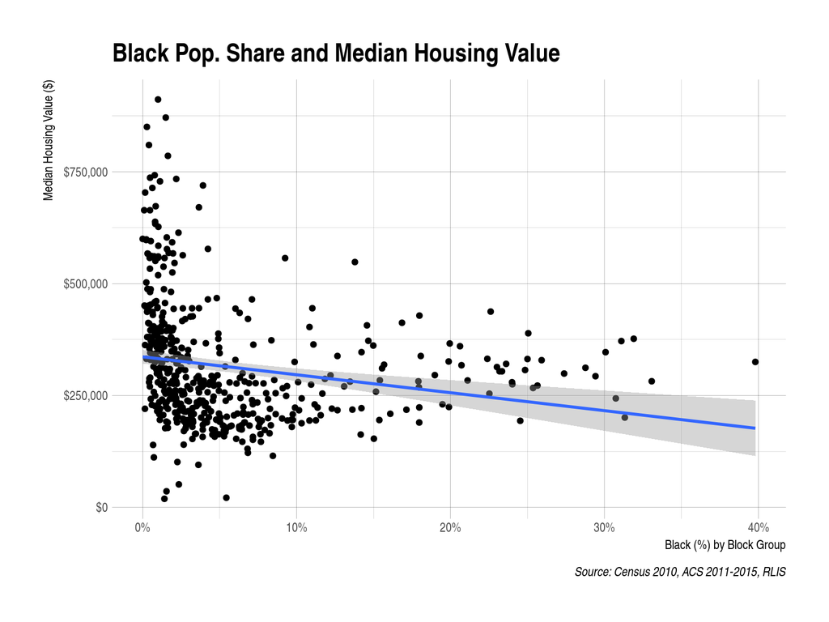

# Some more graphs…

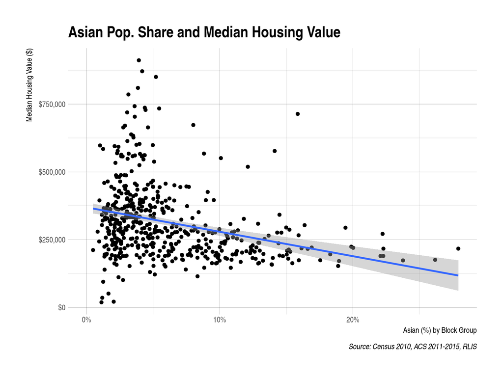

# One More Graph…I swear

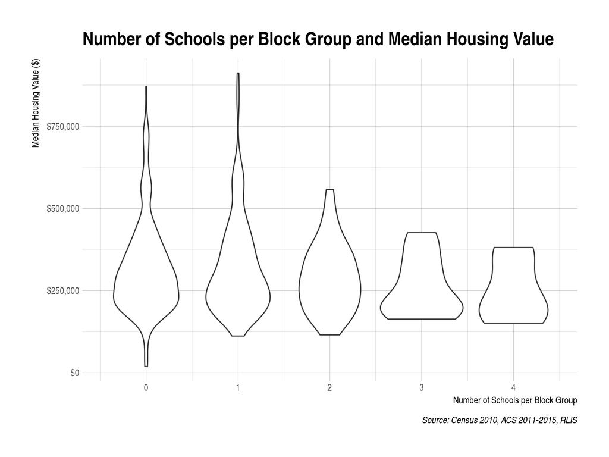

# Let’s run some models! (Note this is definitely not the be best specification)

Keeping it straight OLS for now…

```r
m1 <- lm(med_hsg_val ~ nh_black_share + nh_asian_share +
           hisp_share, data = mult_school_pgsql)

m2 <- lm(med_hsg_val ~ nh_black_share + nh_asian_share +
           hisp_share + Public, data = mult_school_pgsql)

m3 <- lm(med_hsg_val ~ nh_black_share + nh_asian_share +
           hisp_share + Public + Private, data = mult_school_pgsql)

m4 <- lm(med_hsg_val ~ nh_black_share + nh_asian_share +
           hisp_share + school_count, data = mult_school_pgsql)

stargazer(m1, m2, m3, m4, title = "Effect of Primary Schools on Median Housing Value", type = "html")
```

**Effect of Primary Schools on Median Housing Value**

|  | *Dependent variable:* |  |  |  |
| --- | --- | --- | --- | --- |
|  | med_hsg_val |  |  |  |
|  | (1) | (2) | (3) | (4) |
| nh_black_share | -130,189.200* | -132,952.300* | -134,079.900* | -134,082.500* |
|  | (75,520.100) | (75,630.130) | (75,727.360) | (75,651.240) |
| nh_asian_share | -785,069.700*** | -779,625.800*** | -781,355.600*** | -781,645.200*** |
|  | (105,889.200) | (106,154.500) | (106,301.300) | (105,971.800) |
| hisp_share | -997,225.300*** | -990,434.300*** | -989,787.700*** | -989,939.700*** |
|  | (68,753.960) | (69,317.710) | (69,385.680) | (69,221.960) |
| Public |  | -5,094.599 | -4,939.304 |  |
|  |  | (6,463.926) | (6,477.406) |  |
| Private |  |  | -4,445.861 |  |
|  |  |  | (9,447.101) |  |
| school_count |  |  |  | -4,777.476 |
|  |  |  |  | (5,207.666) |
| Constant | 463,864.200*** | 465,202.700*** | 466,289.100*** | 466,330.700*** |
|  | (10,278.290) | (10,421.520) | (10,682.110) | (10,625.700) |
| Observations | 502 | 502 | 502 | 502 |
| R<sup>2</sup> | 0.393 | 0.394 | 0.394 | 0.394 |
| Adjusted R<sup>2</sup> | 0.389 | 0.389 | 0.388 | 0.389 |
| Residual Std. Error | 107,440.900 (df = 498) | 107,481.800 (df = 497) | 107,566.000 (df = 496) | 107,458.000 (df = 497) |
| F Statistic | 107.479*** (df = 3; 498) | 80.703*** (df = 4; 497) | 64.505*** (df = 5; 496) | 80.794*** (df = 4; 497) |
| *Note:* | p<0.1; p<0.05; p<0.01 |  |  |  |

# Some Interesting Results…let’s map some residuals

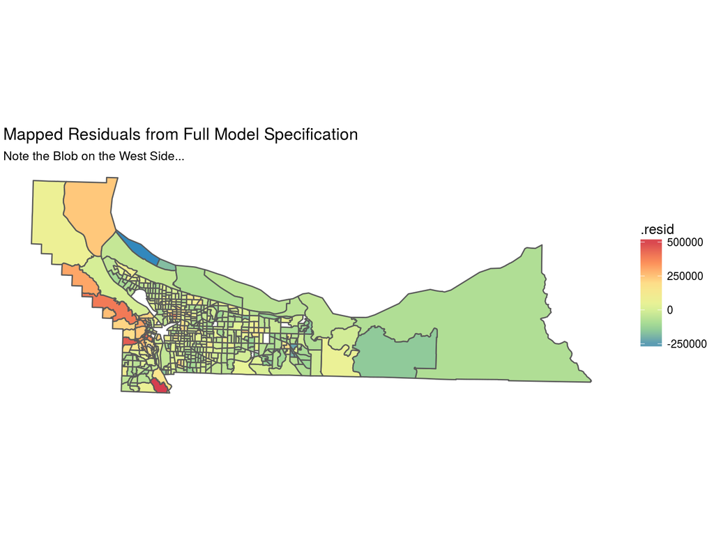

```r
m4_tidy <- augment(m4, mult_school_pgsql)
m4_tidy <- st_as_sf(m4_tidy)

p4 <- ggplot() + theme_ipsum() + theme_void() +
  geom_sf(data = m4_tidy, aes(fill = .resid)) +
  labs(title = "Mapped Residuals from Full Model Specification",
       subtitle = "Note the Blob on the West Side...") +
  scale_fill_distiller(palette = "Spectral")

plot(p4)
```

# We Did a Lot Here

- BUT…we took what is normally a 3-4 application process and brought it to 1
- R provides a flexible, pragmatic platform for a large proportion of most any spatial analytical project
- Thanks to the *sf* package we are not as dependent upon the limitations of existing desktop GIS for jobs they’re not good at (data cleaning, alternative visualiztion and modeling)
- The ability to read and write to PostGIS is a potentially revolutionary shift